# **Supplemental Materials** for “Statements issued by academic medical institutions after George Floyd’s killing by police and subsequent unrest in the United States: cross-sectional study”

Mathew V Kiang and Alexander C Tsai

```r
library(tidyverse)
library(here)
library(DT)
library(knitr)
```

```r
## Read in processed data
analytic_df <- readRDS(here("data_private", "analytic_df.RDS"))
word_df <- readRDS(here("data_private", "tokenized_words.RDS"))
sentence_df <- readRDS(here("data_private", "tokenized_sentences.RDS"))
ngram2_df <- readRDS(here("data_private", "tokenized_bigrams.RDS"))
ngram3_df <- readRDS(here("data_private", "tokenized_trigrams.RDS"))
summary_df <- readRDS(here("data_private", "keyword_summary_df.RDS"))
```

## Introduction

Here, we present analytic code for our paper, “Statements issued by academic medical institutions after George Floyd’s killing by police and subsequent unrest in the United States: cross-sectional study.”

By default, the code is hidden — to view the code, simply click on the “Code” button to the right of each chunk. We used *R version 4.0.0 (2020-04-24)* for all analyses and full session information can be viewed at `./session_info.txt`.

When possible, we save the de-identified intermediate data frames in `csv` format.

## About the data

Here, we import the original, raw data, clean it a bit and assign random ID numbers to each of the institutions. This is what the processing code looks like (found in `./code/01_01_process_raw_data.R`):

```r
## 01_process_raw_data.R ----
##
## Takes the raw data from the Google Sheets (in csv) and creates an analytic
## data frame we can use. Outputs include analytic data frame, mapping of
## random ids to institutions, data frame by words, data frame by bigrams,
## data frame by trigrams, and data frame by sentence.

## Imports ----
library(tidyverse)
library(tidytext)
library(here)
library(janitor)
library(SnowballC)

## Constants ----
CURRENT_FILE_NAME <-
    "current_download.csv"
MANUAL_STOPWORDS <-
    c(
        "00",
        "19",
        "25",
        "3",
        "4",
        "aamc",
        "baltimore",
        "baptist",
        "baylor",
        "brunswick",
        "chicago",
        "college",
        "columbia",
        "cornell",
        "covid",
        "dgsom",
        "dr",
        "duke",
        "forest",
        "georgia",
        "gusom",
        "hopkins",
        "houston",
        "http",
        "irving",
        "jhm",
        "johns",
        "louisville",
        "mayo",
        "minnesota",
        "nashville",
        "northwestern",
        "ohsu",
        "philadelphia",
        "rochester",
        "southwestern",
        "stanford",
        "uchicago",
        "uf",
        "umsom",
        "university",
        "ut",
        "utah",
        "uw",
        "vumc",
        "wake",
        "www.youtube.com",
        "yale"
    )

## Read in data ----
orig_df <-
    readr::read_csv(here::here("data_private", CURRENT_FILE_NAME)) %>%
    janitor::clean_names()

set.seed(123)
analytic_df <- orig_df %>%
    dplyr::filter(keep == 1) %>%
    dplyr::select(-keep, -dplyr::ends_with("_link")) %>%
    dplyr::mutate(date = lubridate::mdy(paste0(date, "/2020"))) %>%
    dplyr::rename(nih_rank = x2018_nih_funding_rank,
                  text = statement_minus_salutation_signature_resources) %>%
    dplyr::mutate(random_id = sample(1:dplyr::n()))

## Tokenize words ----
## Mark all stop words.
word_df <- analytic_df %>%
    tidytext::unnest_tokens(word, text, drop = FALSE) %>%
    dplyr::mutate(stop_word = ifelse(word %in% tidytext::stop_words$word, TRUE, FALSE)) %>%
    dplyr::mutate(stop_word = ifelse(word %in% MANUAL_STOPWORDS, TRUE, stop_word)) %>%
    dplyr::mutate(
        word_stem = SnowballC::wordStem(word),
        stop_word = ifelse(is.na(stop_word), FALSE, stop_word),
        keep_word = !stop_word
    )

## Tokenize sentences ----
sentence_df <- analytic_df %>%
    tidytext::unnest_tokens(sentence, text, drop = FALSE, token = "sentences") %>%
    dplyr::mutate(george_floyd = grepl("[Ff]{1}loyd", sentence))

## Tokenize bigrams ----
ngram2_df <- analytic_df %>%
    tidytext::unnest_ngrams(ngram_orig, text, n = 2, drop = FALSE) %>%
    tidyr::separate(ngram_orig, c("word1", "word2"), sep = " ") %>%
    dplyr::filter(!(word1 %in% c(
        MANUAL_STOPWORDS, tidytext::stop_words$word
    )),
    !(word2 %in% c(
        MANUAL_STOPWORDS, tidytext::stop_words$word
    ))) %>%
    dplyr::mutate(word1_stem = SnowballC::wordStem(word1),
                  word2_stem = SnowballC::wordStem(word2)) %>%
    dplyr::mutate(ngram2 = paste(word1, word2),
                  ngram2_stem = paste(word1_stem, word2_stem))

## Tokenize trigrams
ngram3_df <- analytic_df %>%
    tidytext::unnest_ngrams(ngram_orig, text, n = 3, drop = FALSE) %>%
    tidyr::separate(ngram_orig, c("word1", "word2", "word3"), sep = " ") %>%
    dplyr::filter(!(word1 %in% c(
        MANUAL_STOPWORDS, tidytext::stop_words$word
    )),
    !(word2 %in% c(
        MANUAL_STOPWORDS, tidytext::stop_words$word
    )),
    !(word3 %in% c(
        MANUAL_STOPWORDS, tidytext::stop_words$word
    ))) %>%
    dplyr::mutate(
        word1_stem = SnowballC::wordStem(word1),
        word2_stem = SnowballC::wordStem(word2),
        word3_stem = SnowballC::wordStem(word3)
    ) %>%
    dplyr::mutate(
        ngram3 = paste(word1, word2, word3),
        ngram3_stem = paste(word1_stem, word2_stem, word3_stem)
    )

## Save data ----
## Save analytic df and mapping
saveRDS(analytic_df, here::here("data_private", "analytic_df.RDS"))
readr::write_csv(
    analytic_df %>%
        dplyr::select(institution, nih_rank, usnwr_rank, random_id),
    here::here("data_private", "random_id_mapping.csv")
)

## Save tokenized data
saveRDS(word_df, here::here("data_private", "tokenized_words.RDS"))
saveRDS(sentence_df,
        here::here("data_private", "tokenized_sentences.RDS"))
saveRDS(ngram2_df,
        here::here("data_private", "tokenized_bigrams.RDS"))
saveRDS(ngram3_df,
        here::here("data_private", "tokenized_trigrams.RDS"))
```

### Dimensions

The analytic data frame contains 12 columns and 56 rows (i.e., medical school statements). The columns are:

```r
print(names(analytic_df))
```

```
##  [1] "nih_rank"    "usnwr_rank"  "institution" "public"      "pr"
##  [6] "pr_contact"  "date"        "name"        "position"    "text"
## [11] "statement"   "random_id"
```

In order, the columns represent the institution rank in terms of NIH funding (2018) and US News and World Report (2021), institution name, whether or not the statement is publicly available, date of statement, name of the person who signed the statement (in event of co-signatories the dean and then chancellor were selected), the academic position of the signatory, the text of the statement after removing unnecessary text (i.e., salutations, signature, a list of suggested resources), the full statement, and our newly created random ID variable.

## List institutions included in the data set

A total of 56 statements are included in the data set. The institutions, listed in alphabetical order, are:

```r
analytic_df %>%
  arrange(institution) %>%
  transmute(institution,
            institution_star =
              paste0(
                institution,
                ifelse(public == 0, "*", ""),
                ifelse(!grepl("[Dd]{1}ean", position), "^", "")
              ),
            nih_rank,
            usnwr_rank) %>%
  select(-institution_star) %>%
  knitr::kable(
    format = "html",
    digits = 0,
    col.names = c("Institution", "NIH Funding Rank (2018)", "USN&WR Rank (2021)")
  )
```

| Institution | NIH Funding Rank (2018) | USN&WR Rank (2021) |
| --- | --- | --- |
| Albert Einstein College of Medicine | 32 | 40 |
| Baylor College of Medicine | 20 | 22 |
| Boston University | 45 | 29 |
| Brown University (Alpert) | 66 | 38 |
| Case Western Reserve University | 31 | 24 |
| Cleveland Clinic Lerner COM CWRU | 50 | NA |
| Columbia University | 8 | 6 |
| Cornell University (Weill) | 33 | 11 |
| Dartmouth College (Geisel) | 57 | 50 |
| Duke University | 9 | 12 |
| Emory University | 18 | 24 |
| Georgetown University | 78 | 44 |
| Harvard University | 26 | 1 |
| Icahn School of Medicine at Mount Sinai | 13 | 20 |
| Indiana University Indianapolis | 36 | 47 |
| Johns Hopkins University | 2 | 2 |
| Mayo Clinic School of Medicine | 22 | 6 |
| Medical College of Wisconsin | 49 | NA |
| Medical University of South Carolina | 43 | 58 |
| New York University (Grossman) | 19 | 4 |
| Northwestern University (Feinberg) | 16 | 18 |
| Ohio State University | 48 | 34 |
| Oregon Health and Science University | 25 | 28 |
| Stanford University | 3 | 4 |
| University of Alabama Birmingham | 21 | 31 |
| University of California Davis | 29 | 40 |
| University of California Irvine | 56 | 44 |
| University of California Los Angeles (Geffen) | 14 | 6 |
| University of California San Diego | 12 | 21 |
| University of California San Francisco | 1 | 6 |
| University of Chicago (Pritzker) | 38 | 17 |
| University of Cincinnati | 62 | 44 |
| University of Colorado | 23 | 31 |
| University of Florida | 46 | 40 |
| University of Iowa (Carver) | 41 | 34 |
| University of Kentucky | 47 | 68 |
| University of Maryland | 35 | 34 |
| University of Massachusetts Worcester | 34 | 47 |
| University of Miami (Miller) | 40 | 50 |
| University of Michigan Ann Arbor | 10 | 15 |
| University of Minnesota | 30 | 40 |
| University of North Carolina Chapel Hill | 17 | 23 |
| University of Pennsylvania (Perelman) | 5 | 3 |
| University of Pittsburgh | 6 | 14 |
| University of Rochester | 39 | 34 |
| University of South Florida | 85 | 47 |
| University of Southern California (Keck) | 27 | 31 |
| University of Texas Southwestern Medical Center | 28 | 26 |
| University of Utah | 37 | 38 |
| University of Virginia | 42 | 29 |
| University of Washington | 15 | 13 |
| University of Wisconsin Madison | 24 | 27 |
| Vanderbilt University | 11 | 18 |
| Wake Forest University Health Sciences | 44 | 52 |
| Washington University in St. Louis | 4 | 6 |
| Yale University | 7 | 15 |

Of the 56 statements, 10 (17.9%) were not easily accessible on the institution’s website or official social media accounts and 3 (5.4%) were not from a medical school dean.

## Dates of statements

All statements occurred between 2020-05-29 and 2020-06-22 with 1 undated statement.

```r
analytic_df %>%
  count(date)
```

```
## # A tibble: 11 x 2
##    date           n
##    <date>     <int>
##  1 2020-05-29     2
##  2 2020-05-30     6
##  3 2020-05-31    12
##  4 2020-06-01    20
##  5 2020-06-02     6
##  6 2020-06-03     3
##  7 2020-06-04     3
##  8 2020-06-07     1
##  9 2020-06-11     1
## 10 2020-06-22     1
## 11 NA             1
```

The median and IQR of dates is:

```r
sort(analytic_df$date)[c(round(.5 * NROW(analytic_df)),
                         round(.25 * NROW(analytic_df)),
                         round(.75 * NROW(analytic_df)))]
```

```
## [1] "2020-06-01" "2020-05-31" "2020-06-02"
```

## Descriptive statistics of statements

### Total number of unique words (excluding stop words)

```r
word_df %>%
  filter(keep_word) %>%
  pull(word) %>%
  n_distinct()
```

```
## [1] 3153
```

### Total number of words (including repeats, excluding stop words)

```r
word_df %>%
  filter(keep_word) %>%
  NROW()
```

```
## [1] 10971
```

### Total number of sentences

```r
sentence_df %>%
  NROW()
```

```
## [1] 1180
```

Note that counting sentences is a rough approximation because things like “Mr.” will count as their own sentence.

### Words by institution (including repeats and stop words)

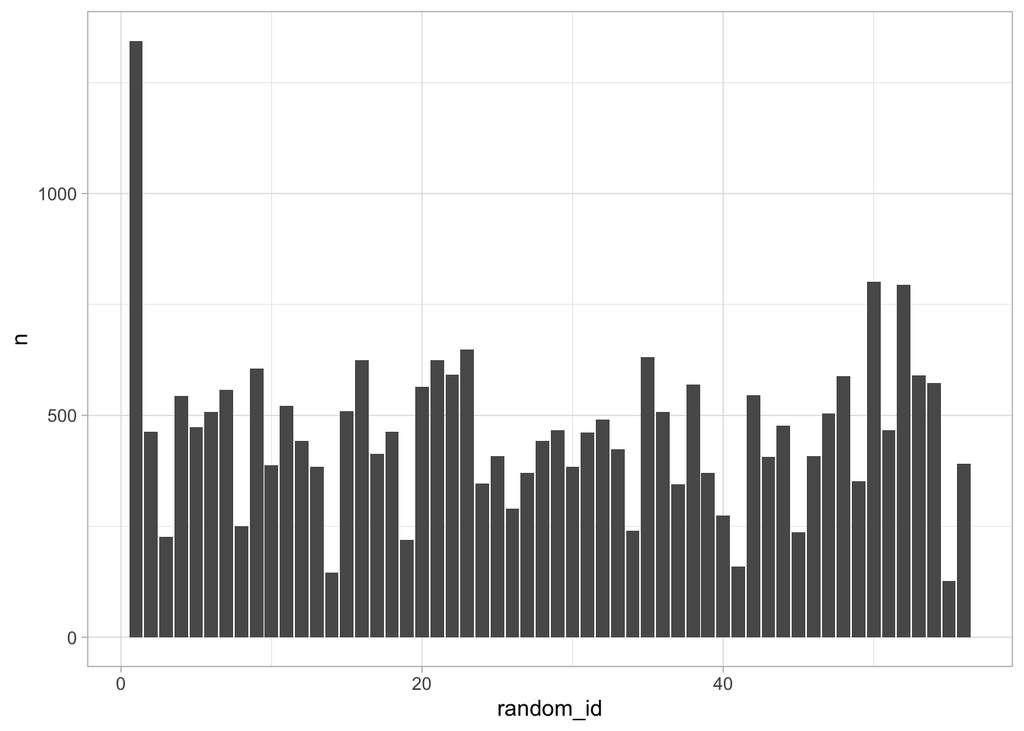

```r
x <- word_df %>%
    count(random_id, sort = TRUE)

ggplot(x, aes(x = random_id, y = n)) +
    geom_col() +
    theme_light()
```

```r
summary(x$n)
```

```
##    Min. 1st Qu.  Median    Mean 3rd Qu.    Max.
##   126.0   371.0   464.0   463.6   559.5  1344.0
```

### Words by institution (including repeats, excluding stop words)

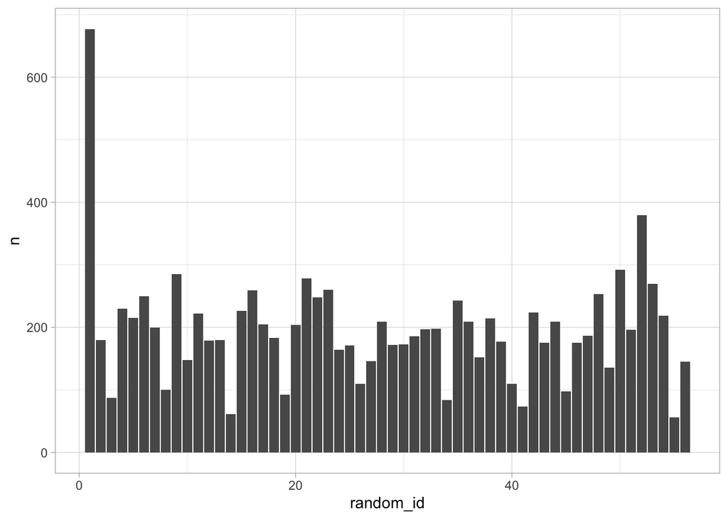

```r
x <- word_df %>%
    filter(keep_word) %>%
    count(random_id, sort = TRUE)

ggplot(x, aes(x = random_id, y = n)) +
    geom_col() +
    theme_light()
```

```r
summary(x$n)
```

```
##    Min. 1st Qu.  Median    Mean 3rd Qu.    Max.
##    56.0   151.0   191.5   195.9   224.5   677.0
```

## Most common words and n-grams

### 100 most common words and word stems

Here, we tabulate the frequency of each `word_stem` and `word`. The `n_word_stem` and `n_word` columns show the frequency of stems and words, respectively. The `n_inst_*` columns show the number of unique institutes that used each word. Sorting by `n_inst_word` will result in the words that were used by the highest number of different institutions.

```r
x <- word_df %>%
    filter(keep_word) %>%
    group_by(word_stem) %>%
    mutate(n_word_stem = n(),
           n_inst_word_stem = n_distinct(random_id)) %>%
    group_by(word) %>%
    mutate(n_word = n(), n_inst_word = n_distinct(random_id)) %>%
    select(word_stem,
           word,
           n_word_stem,
           n_inst_word_stem,
           n_word,
           n_inst_word) %>%
    distinct() %>%
    ungroup() %>%
    mutate(stem_rank = min_rank(desc(n_word_stem))) %>%
    filter(stem_rank <= 100) %>%
    arrange(desc(n_word_stem))

write_csv(x, here("data", "top_100_words.csv"))

x %>%
    datatable(rownames = FALSE)
```

| word_stem | word | n_word_stem | n_inst_word_stem | n_word | n_inst_word | stem_rank |
| --- | --- | --- | --- | --- | --- | --- |
| commun | communities | 223 | 52 | 51 | 31 | 1 |
| commun | community | 223 | 52 | 167 | 52 | 1 |
| commun | communications | 223 | 52 | 1 | 1 | 1 |
| commun | communicate | 223 | 52 | 1 | 1 | 1 |
| commun | communication | 223 | 52 | 3 | 2 | 1 |
| health | health | 167 | 51 | 167 | 51 | 6 |
| racism | racism | 118 | 42 | 118 | 42 | 7 |
| time | times | 76 | 43 | 20 | 15 | 8 |
| time | time | 76 | 43 | 56 | 34 | 8 |
| black | black | 75 | 28 | 75 | 28 | 10 |

[output cut: 99 more lines]

### 100 most common 2-gram phases

Below, we show the top 100 most commonly used 2-gram phrases in both the stemmed and unstemmed format. Similar to above, we show the counts (`n_ngram_stem` for the stemmed version and `n_ngram` for the unstemmed version) as well as the number of unique institutions that used the phrase (e.g., `n_inst_ngram_stem` for the stemmed version).

```r
x <- ngram2_df %>%
    group_by(ngram2_stem) %>%
    mutate(n_ngram_stem = n(),
           n_inst_ngram_stem = n_distinct(random_id)) %>%
    group_by(ngram2) %>%
    mutate(n_ngram = n(),
           n_inst_ngram = n_distinct(random_id)) %>%
    select(ngram2_stem,
           ngram2,
           n_ngram_stem,
           n_inst_ngram_stem,
           n_ngram,
           n_inst_ngram) %>%
    distinct() %>%
    ungroup() %>%
    mutate(stem_rank = min_rank(desc(n_ngram_stem))) %>%
    filter(stem_rank <= 100) %>%
    arrange(desc(n_ngram_stem))

write_csv(x, here("data", "top_100_bigrams.csv"))

x %>%
    datatable(rownames = FALSE)
```

| ngram2_stem | ngram2 | n_ngram_stem | n_inst_ngram_stem | n_ngram | n_inst_ngram | stem_rank |
| --- | --- | --- | --- | --- | --- | --- |
| african american | african american | 55 | 24 | 26 | 16 | 1 |
| african american | african americans | 55 | 24 | 29 | 16 | 1 |
| georg floyd | george floyd | 50 | 45 | 50 | 45 | 3 |
| health care | health care | 34 | 20 | 34 | 20 | 4 |
| ahmaud arberi | ahmaud arbery | 27 | 26 | 27 | 26 | 5 |
| breonna taylor | breonna taylor | 24 | 23 | 24 | 23 | 6 |
| public health | public health | 20 | 15 | 20 | 15 | 7 |
| health dispar | health disparities | 19 | 12 | 19 | 12 | 8 |
| structur racism | structural racism | 17 | 11 | 17 | 11 | 9 |
| medic school | medical school | 17 | 13 | 14 | 11 | 9 |

[output cut: 102 more lines]

### Most common 3-gram phrases

Like above but for three word phrases

```r
x <- ngram3_df %>%
    group_by(ngram3_stem) %>%
    mutate(n_ngram_stem = n(),
           n_inst_ngram_stem = n_distinct(random_id)) %>%
    group_by(ngram3) %>%
    mutate(n_ngram = n(),
           n_inst_ngram = n_distinct(random_id)) %>%
    select(ngram3_stem,
           ngram3,
           n_ngram_stem,
           n_inst_ngram_stem,
           n_ngram,
           n_inst_ngram) %>%
    distinct() %>%
    ungroup() %>%
    filter(n_ngram_stem > 1) %>%
    arrange(desc(n_ngram_stem))

write_csv(x, here("data", "top_trigrams.csv"))

x %>%
    datatable(rownames = FALSE)
```

| ngram3_stem | ngram3 | n_ngram_stem | n_inst_ngram_stem | n_ngram | n_inst_ngram |
| --- | --- | --- | --- | --- | --- |
| martin luther king | martin luther king | 8 | 7 | 8 | 7 |
| african american commun | african american community | 7 | 6 | 7 | 6 |
| luther king jr | luther king jr | 6 | 6 | 6 | 6 |
| georg floyd breonna | george floyd breonna | 5 | 5 | 5 | 5 |
| floyd breonna taylor | floyd breonna taylor | 5 | 5 | 5 | 5 |
| georg floyd ahmaud | george floyd ahmaud | 5 | 5 | 5 | 5 |
| floyd ahmaud arberi | floyd ahmaud arbery | 5 | 5 | 5 | 5 |
| georg floyd’ death | george floyd’s death | 4 | 4 | 4 | 4 |
| public health crisi | public health crisis | 4 | 4 | 4 | 4 |
| medic center commun | medical center community | 4 | 3 | 4 | 3 |

[output cut: 50 more lines]

### 5 most common word stems for each institution

```r
x <- word_df %>%
    filter(keep_word) %>%
    group_by(random_id, word_stem) %>%
    mutate(n = n()) %>%
    select(random_id, word_stem, word, n) %>%
    distinct() %>%
    group_by(random_id) %>%
    arrange(desc(n), .by_group = TRUE) %>%
    slice(1:5) %>%
    ungroup()

write_csv(x, here("data", "top_5_common_wordstems_by_institution.csv"))

x %>%
    datatable(rownames = FALSE)
```

| random_id | word_stem | word | n |
| --- | --- | --- | --- |
| 1 | divers | diversity | 18 |
| 1 | divers | diverse | 18 |
| 1 | umm | umms | 12 |
| 1 | commun | community | 10 |
| 1 | faculti | faculty | 9 |
| 2 | commun | community | 7 |
| 2 | commun | communities | 7 |
| 2 | remind | reminded | 4 |
| 2 | remind | remind | 4 |
| 2 | social | social | 3 |

[output cut: 270 more lines]